# Data Visualization

# Add a `geom_`

Our plot has appropriate axes now that we’ve mapped the data, but the canvas is blank because we’ve not told R how to represent the data. Our inspiration plot uses lines, so we will too.

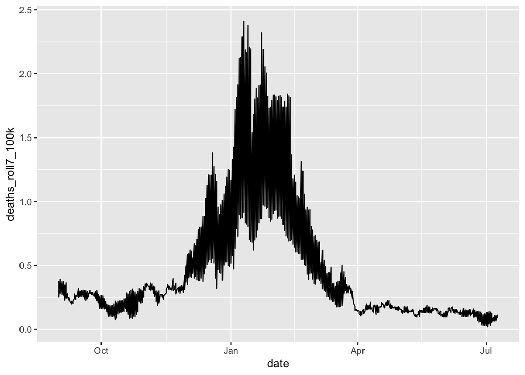

```r
  ggplot(covid, aes(x = date, y = deaths_roll7_100k)) +
    geom_line()
```

This does not look right because we did not tell R that the data are grouped. `covid` is a ‘long’ dataset with two series:: Arizona and North Carolina. Which variable contains this grouping information?

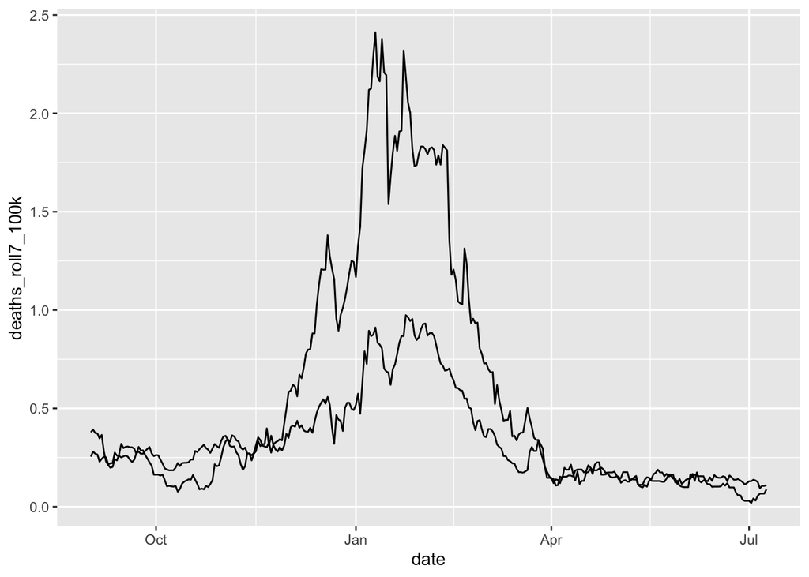

```r
  ggplot(covid, aes(x = date,
                    y = deaths_roll7_100k,
                    group = Province_State)) +
    geom_line()
```

We need to add color to identify each state’s line. One point of friction for new users is deciding whether to use `color` or `fill`. Remember this: Lines and points use `color`. Rather than specifying `group` explicitly, we can simplify to `color`, which implicitly tells R that we’re coloring by group.

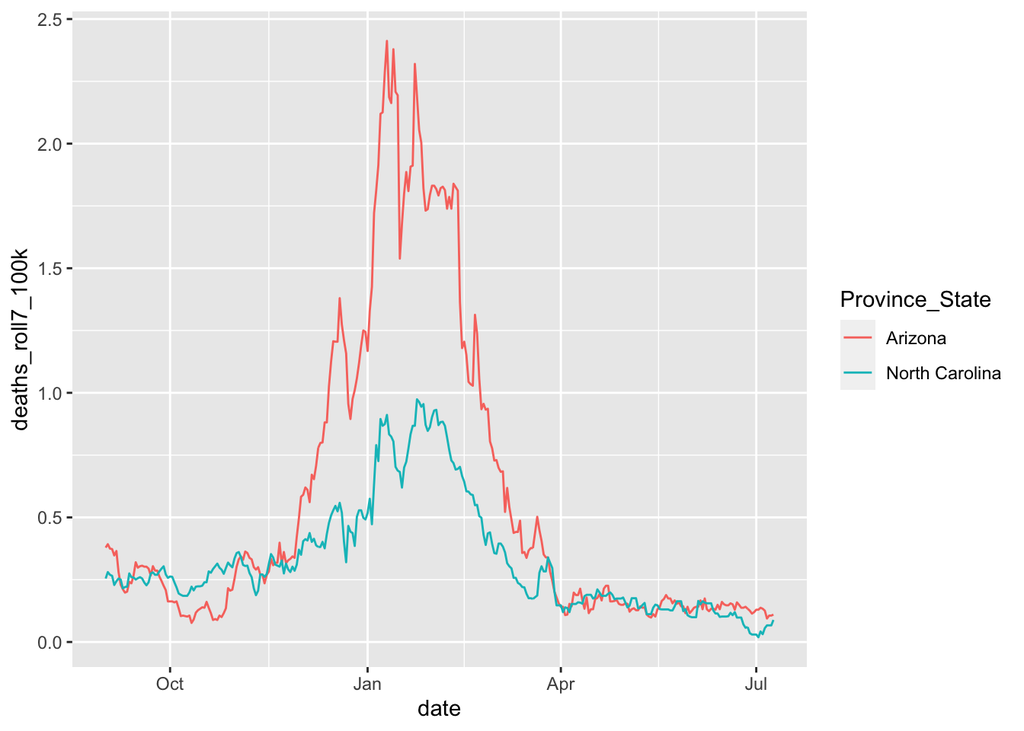

```r
  ggplot(covid, aes(x = date,
                    y = deaths_roll7_100k,
                    color = Province_State)) +
    geom_line()
```

# Modify the look

We’ll dig into plot refinements after the break. For now, just take note of the layering approach.

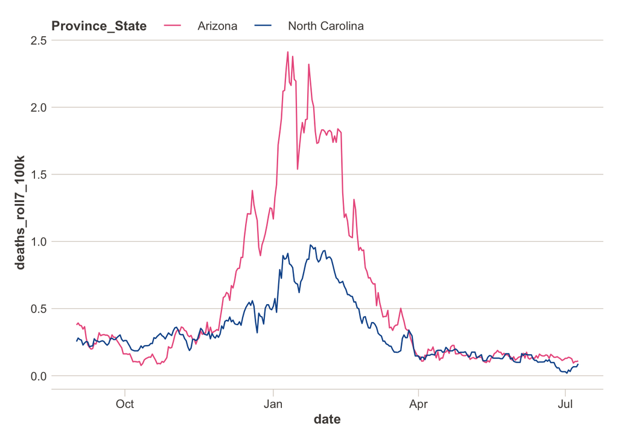

```r
  ggplot(covid,                                     # data
         aes(x = date,                              # mapping
             y = deaths_roll7_100k,
             color = Province_State)) +
         geom_line() +                              # geom
         scale_color_manual(values = c(             # theme
                                       "#eb5e8d",     # pink
                                       "#0f5599"      # blue
                                       )) +
        ft_theme()
```